# What socio-demographic factors influence European’s willingness to commit to individual climate change adaptation and mitigation measures

Jana Kalmbach

2022-03-28

# 1 Introduction

Awareness and concern about climate change did globally rise in the past decades (Driscoll 2019). However, while some young adolescents go on the streets on Fridays to demonstrate for a need for immediate action, others deny that climate change even exists. Sociological research has examined what socio-demographic factors are potentially related to certain attitudes towards climate change. Researchers suggest correlations with age (Krkoška Lorencová, Loučková, and Vačkářů 2019; Poortinga et al. 2019), gender (Korkmaz 2018), race (Ballew et al. 2020) income and education (Ballew et al. 2020; Poortinga et al. 2019), unemployment (Benegal 2018), and having adolescent children or grandchildren (Lawson et al. 2019). Additionally, research stresses a high correlation between climate change attitudes and political orientation. For instance, Huber (2020) found a significant correlation between climate skepticism and populist worldviews in the US. Additionally, Krange, Kaltenborn, and Hultman (2019) state that conservative, white males tend to hold the highest share of climate skeptics in Norway. In his metanalysis, Hornsey et al. (2016) concluded that attitudes towards climate change are better explained by political orientation, ideologies, and worldviews than other socio-demographic factors. However, Lewis, Palm, and Feng (2019) criticize than many researchers focus solely on the US, while party identification and political ideology seem to matter much less across the globe.

To assess the situation in Europe, this research aims to explore **which socio-demographic factors influence European’s willingness to personally commit to climate change adaptation and mitigation measures**. Taken measures include for instance the restriction of individual consumption or the conscious decision to consume more regional and environmentally friendly products. Based on data of the climate survey of the European Investment bank conducted in 2021, climate scores are calculated of all German, French, Swedish, Portuguese, and Finish participants. A multiple linear regression is applied to test for correlations between climate score and socio-demographic factors. Additionally, socio-demographic factors of 5% of the participants achieving the highest and lowest climate score are compared. Even though this study has some statistical and theoretical limitations, it nevertheless contributes to the research about potential predictors for certain attitudes towards climate change. Such research might be relevant to better target climate change communication or policies.

# 2 Methods

For this study, data is retrieved from the European Investment Bank, that has conducted a climate survey every year since 2018 (European Investment Bank n.d.). Since the different rounds are not directly comparable due to varying questions, this study focuses only on the last round conducted in August and September 2021. Interviewees participated at the self-administered survey online in all 27 EU countries, the UK, China, and the US. Respondents were randomly selected among nationally representative panels. The total sample includes 30.662 participants aged 15 and older. Depending on the amount of inhabitants per country, the sample size ranged from 500 to 2.000, except Malta (n=200) and Cyprus (n=462). The representativity of the data was ensured by the quota method and samples in each country were weighted according to gender, age, occupation, and region. To reduce the amount of data, this study focuses only on Germany, France, Sweden, Portugal, and Finland (n = 6.999). The countries are chosen for their major contribution to European emissions (Germany, France) (European Parliament 2018), because they were specifically mentioned in the literature (Brink and Wamsler 2019), or because of their location in Europe.

## 2.1 Hypothesis

*H0: Some socio-demographic factors could potentially serve as predictors for European’s willingness to commit to climate change adaptation and mitigation measures.*

*H1: Socio-demographic factors cannot serve as predictors for European’s willingness to commit to climate change adaptation and mitigation measures.*

To test the null-hypothesis, survey questions that point towards individuals’ willingness for climate change adaptation and mitigation measures are determined. Depending on the answer of participants to these questions, their individual climate score is calculated. Then, a multiple linear regression is conducted to explore whether a high score correlates with country, age, gender, occupation, political affiliation, or population density of home. For further analysis, the number of participants that deny anthropogenic climate change are identified and their mean climate score is compared to the entire sample. Moreover, the socio-demographic factors of the 175 individuals (5% of the sample) with the highest and lowest climate scores respectively are compared.

# 3 Results

First, the climate score is calculated.

```r
climate_score <- dat %>%
  select(c(Q3:Q18)) %>%
  rowSums()
```

## 3.1 Descriptive analysis of climate score

```r
tmp <- describe(climate_score)  # create a descriptive summary
tmp$var <- var(climate_score)   # add the variance
#rename row and column names
rownames(tmp) <- "Climate score"
colnames(tmp) <- c("vars",  "n",    "mean", "standard deviation",   "median",   "trimmed mean", "mad",  "min",  "max", "range", "skewness", "kurtosis", "se",   "variance")
# display the descriptive summary as table
knitr::kable(tmp, caption = "Summary of climate score", digits = 3)
```

Table 3.1: Summary of climate score

|  | vars | n | mean | standard deviation | median | trimmed mean | mad | min | max | range | skewness | kurtosis | se | variance |
| --- | --- | --- | --- | --- | --- | --- | --- | --- | --- | --- | --- | --- | --- | --- |
| Climate score | 1 | 6999 | 40.957 | 7.685 | 42 | 41.165 | 7.413 | 19 | 59 | 40 | -0.236 | -0.472 | 0.092 | 59.052 |

In Figure 3.1, the climate score is represented as a histogram and a boxplot.

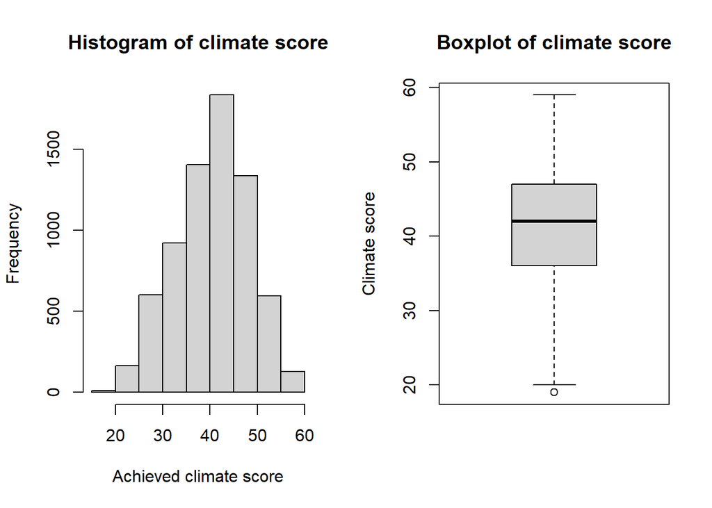

Figure 3.1: Histogram and boxplot representation of climate score of the sample

```r
par(mfrow = c(1,2)) # 2 plots in 1 column
hist(climate_score,  main="Histogram of climate score",
     xlab="Achieved climate score",
     ylab="Frequency")
boxplot(climate_score, main="Boxplot of climate score",
        ylab="Climate score")
```

As can be seen from Table 3.1 and Figure 3.1, there are more individuals that have higher climate scores than those with lower ones. We can express this by categorizing the participants willingness to commit to climate change adaptation and mitigation measures into below average, medium, and above average (see Table 3.2).

```r
cat <- table(cut(x = climate_score, breaks = 3,
                             labels = c("below average", "medium", "above average")))
# add proportinal share to table
prop <- cat %>% prop.table %>% round(3)
climate_score_cat <- as.data.frame(cat)
climate_score_cat$prop <- prop
# rename columns
colnames(climate_score_cat) <- c("Climate score performance", "Number of individuals", "Proportions")
# display as table
knitr::kable(climate_score_cat, caption = "Climate score distribution among individuals", digits = 3)
```

Table 3.2: Climate score distribution among individuals

| Climate score performance | Number of individuals | Proportions |
| --- | --- | --- |
| below average | 1099 | 0.157 |
| medium | 3838 | 0.548 |
| above average | 2062 | 0.295 |

## 3.2 Linear regression exploring socio-demographic factors

A multiple linear regression is performed to test whether the climate score correlates with age, gender, country, children under 18 years-old, occupation, political affiliation, and population density of home.

```r
lm1 <- lm(formula = climate_score ~ origage + gender + country + children.18.yo + occupation + left.right + pop.density, data = dat)
stargazer(lm1, type = "html") # display as table
```

|  | *Dependent variable:* |
| --- | --- |
|  | climate_score |
| origage | -0.036 |
|  | (0.089) |
| gender | -1.494*** |
|  | (0.195) |
| country | -0.043 |
|  | (0.077) |
| children.18.yo | 0.893*** |
|  | (0.221) |
| occupation | -0.288* |
|  | (0.168) |
| left.right | -0.407*** |
|  | (0.046) |
| pop.density | -0.496*** |
|  | (0.127) |
| Constant | 45.944*** |
|  | (0.708) |
| Observations | 6,292 |
| R<sup>2</sup> | 0.030 |
| Adjusted R<sup>2</sup> | 0.029 |
| Residual Std. Error | 7.594 (df = 6284) |
| F Statistic | 27.536*** (df = 7; 6284) |
| *Note:* | p<0.1; p<0.05; p<0.01 |

The multiple linear regression shows a significant correlation between climate score and gender, children under 18 years old, political affiliation, and population density. The other factors are not significantly correlated. The R squared value is 0.029. It should be mentioned that 707 values were excluded because the data about political affiliation contained unknown values.

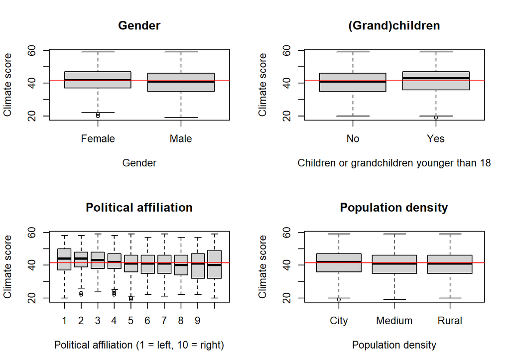

Figure 3.2: Boxplots showing climate score by gender, having children or grandchildren under 18 years-old, political affilation, and population density of neighbourhood.

```r
par(mfrow = c(2,2)) # 2 plots per column, 2 columns
boxplot(climate_score ~ factor_dat$gender, ylab = "Climate score", xlab = "Gender", main = "Gender")
abline(h = 41.35, col = "red")  # add line of mean climate score of sample
boxplot(climate_score ~ factor_dat$children.18.yo, ylab = "Climate score", xlab = "Children or grandchildren younger than 18", main = "(Grand)children")
abline(h = 41.35, col = "red")
boxplot(climate_score ~ dat$left.right, ylab = "Climate score", xlab = "Political affiliation (1 = left, 10 = right)", main = "Political affiliation")
abline(h = 41.35, col = "red")
boxplot(climate_score ~ factor_dat$pop.density, ylab = "Climate score", xlab = "Population density", main = "Population density")
abline(h = 41.35, col = "red")
```

## 3.3 Exploration of climate score, political affiliation, and other factors

Since political orientation is discussed in the literature as a new but essential predictor, further analysis will specifically focus on the relationships between climate score, political affiliation, and all other significant predictors. The code for the plots displayed in Figure 3.3 is exemplarily displayed here for age.

```r
# Age groups are added as categorical data
dat$lorigage <- factor_dat$origage

# relation between climate score, political affiliation, and age groups is plotted
orage <- ggplot(dat,
       aes(x = climate_score,
           y = left.right,
           color = lorigage)) +
  geom_point(size = .9,
             alpha = .3, color = "grey") +
  geom_smooth(method = "lm") +
  theme_bw() +
  labs(x = "Climate score",
       y = "Political affiliation",
       color = "Age groups")
```

Repeating the same step for the other factors results in Figure 3.3.

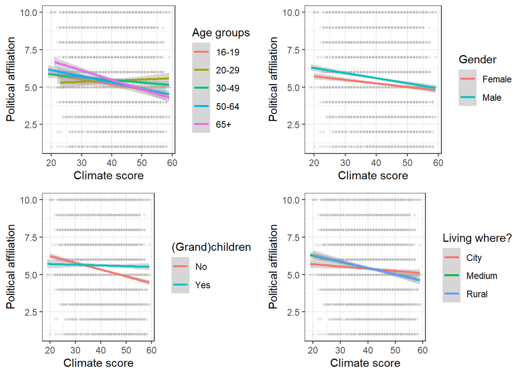

Figure 3.3: A closer examination of the relationship between climate score, political affiliation, and other factors

```r
# Plot all four graphs
figure <- ggarrange(orage, gndr, chdrn, cty,
                    ncol = 2, nrow = 2)
figure
```

Figure 3.3 shows tendencies between political affiliation, climate score and other factors. For instance, young adults (20-29 years) seem to achieve higher climate scores if they are slightly oriented towards the right end of the conservative spectrum and lower climate scores if they tend towards the left. Contrarily, for older participants (50+) the opposite seems to be the case. Concerning gender, both groups achieve higher scores if they tend towards the conservative to left-wing end. Additionally, females seem to have a higher tendency for the left spectrum than males. Interestingly, having young children or grandchildren seems to level out political affiliation, while participants without young family members achieve better climate scores if they are rather left-oriented. Lastly, people in rural areas and small or medium cities seem to be more environmentally conscious when being on the left end of the conservative spectrum. This relation is less strong but present for people living in big cities.

## 3.4 Comparative analysis of participants with low and high climate scores

```r
# order participants based on climate scores
c_ordered <- factor_dat[order(factor_dat$climate_score),]
# extract participants with lowest and highest scores
lowc <- c_ordered[1:175, ]
highc <- c_ordered[6825:6999,]
```

```r
# combine into one data frame
cc <- rbind(lowc, highc)
# add id for each participant
cc$id <- 1:nrow(cc)
```

A plot is computed for each socio-demographic variable. See plot ‘a’ as example:

```r
a <- ggplot(cc, aes(fill=country, x=cc, y=id)) +
      geom_bar(position='fill', stat='identity')
```

Figure 3.4 and 3.5 graphically compare all socio-demographic factors for the 5% of the sample with the lowest and highest climate scores. It seems that Swedish and Finish participants generally tend to have lower climate scores. Contrarily, Portuguese and French people tend towards higher scores. For occupation, higher shares of net economically active and unemployed people achieve higher scores than lower ones. For all other factors, the plots mirror the previous findings.

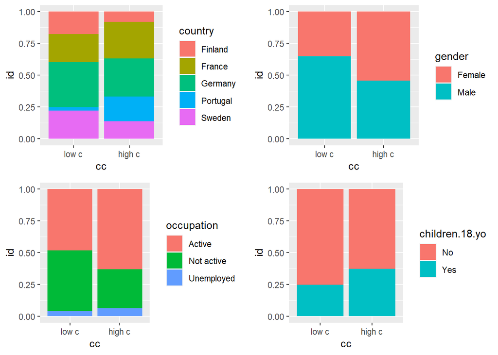

Figure 3.4: Socio-demographic factors in comparison for participants with lowest and highest climate scores

```r
figure1 <- ggarrange(a, b, c, d,
                    ncol = 2, nrow = 2)
figure1
```

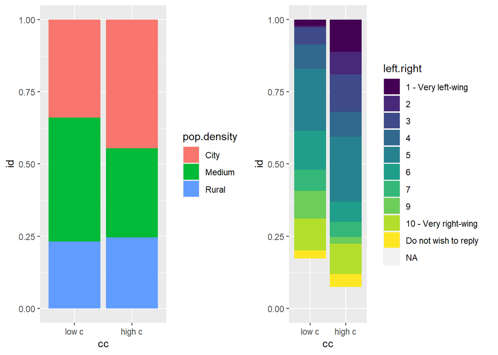

Figure 3.5: Socio-demographic factors in comparison for participants with lowest and highest climate scores

```r
figure2 <- ggarrange(e,f,
                    ncol = 2, nrow = 1)
figure2
```

## 3.5 Additional analysis: Identification of climate deniers

In Question 6 of the survey, participants are asked on their opinion why it is so difficult to solve the climate crisis. Two of the answering options let assume that participants do not believe in anthropogenic climate change.

```r
cdeniers <- factor_dat[factor_dat$Q6 == 'There is no climate crisis, it is a hoax'|factor_dat$Q6 =='Because global warming is not due to human activities, so our actions won’t make a difference', ]
```

From Table 3.3 we can see that 886 participants do not believe in anthropogenic climate change. This equals to more than 12% of the sample. The mean climate score is with 37.4 points almost 4 points lower than of the average participant.

```r
tmpp <- describe(cdeniers$climate_score) # create a summary
knitr::kable(tmpp, caption = "Summary of climate score of climate deniers", digits = 3)
```

Table 3.3: Summary of climate score of climate deniers

|  | vars | n | mean | sd | median | trimmed | mad | min | max | range | skew | kurtosis | se |
| --- | --- | --- | --- | --- | --- | --- | --- | --- | --- | --- | --- | --- | --- |
| X1 | 1 | 886 | 37.377 | 9.015 | 37 | 37.169 | 10.378 | 19 | 59 | 40 | 0.154 | -0.929 | 0.303 |

# 4 Discussion

The results of this study mostly agree with the literature. The only difference is that there was no significant correlation between the climate score and age or occupation. Although the results should be seen with caution due to the simple analytical tools used, the null hypothesis can be accepted. Thus, there seems to be a significant correlation between some socio-demographic factors and the willingness to commit to climate change adaptation and mitigation measures in this sample. Nevertheless, there are some major limitations to this study that need to be addressed.

# 5 Conclusion

Overall, this study found a correlation between socio-demographic factors and Europeans’ willingness to commit to climate change adaptation and mitigation measures. Gender, political affiliation, having children or grandchildren younger than 18 years-old, and the population density of neighborhood were found to be predictors at a significant level. Generally, females with children or grandchildren that live in a city or metropolis and tend towards the left spectrum seem to be most willing to pursue a climate friendly lifestyle. Additionally, it seems that Portuguese and French are more willing to transform to a sustainable lifestyle than Fins and Swedes. In total, 12% of the sample does not believe in anthropogenic climate change. However, the results should be seen with caution because of statistical and theoretical limitations to this study. Generally, this study should also not be used to enhance existing stereotypes but might contribute to specifically address groups that do not yet thrive to reduce their emission footprint and to study their reasons and circumstances.

# References

Ballew, Matthew T., Adam R. Pearson, Matthew H. Goldberg, Seth A. Rosenthal, and Anthony Leiserowitz. 2020. “Does Socioeconomic Status Moderate the Political Divide on Climate Change? The Roles of Education, Income, and Individualism.” *Global Environmental Change* 60 (January): 102024. https://doi.org/10.1016/j.gloenvcha.2019.102024.

Benegal, Salil D. 2018. “The Impact of Unemployment and Economic Risk Perceptions on Attitudes Towards Anthropogenic Climate Change.” *Journal of Environmental Studies and Sciences* 8 (3): 300–311. https://doi.org/10.1007/s13412-017-0452-7.

Brink, Ebba, and Christine Wamsler. 2019. “Citizen Engagement in Climate Adaptation Surveyed: The Role of Values, Worldviews, Gender and Place.” *Journal of Cleaner Production* 209 (February): 1342–53. https://doi.org/10.1016/j.jclepro.2018.10.164.

Driscoll, Daniel. 2019. “Assessing Sociodemographic Predictors of Climate Change Concern, 1994–2016.” *Social Science Quarterly* 100 (5): 1699–1708. https://doi.org/10.1111/ssqu.12683.

European Investment Bank. n.d. “Climate Survey Resources.” *EIB.org*. Accessed March 3, 2022. https://www.eib.org/en/surveys/climate-survey/all-resources.htm.

European Parliament. 2018. “Greenhouse Gas Emissions by Country and Sector.” https://www.europarl.europa.eu/news/en/headlines/society/20180301STO98928/greenhouse-gas-emissions-by-country-and-sector-infographic.

Hornsey, Matthew J., Emily A. Harris, Paul G. Bain, and Kelly S. Fielding. 2016. “Meta-Analyses of the Determinants and Outcomes of Belief in Climate Change.” *Nature Climate Change* 6 (6): 622–26. https://doi.org/10.1038/nclimate2943.

Huber, Robert A. 2020. “The Role of Populist Attitudes in Explaining Climate Change Skepticism and Support for Environmental Protection.” *Environmental Politics* 29 (6): 959–82. https://doi.org/10.1080/09644016.2019.1708186.

Korkmaz, M. 2018. “Public Awareness and Perceptions of Climate Change: Differences in Concern about Climate Change in the West Meditteranean Region of Turkey.” *Applied Ecology and Environmental Research* 16 (4): 4039–50. https://doi.org/10.15666/aeer/1604_40394050.

Krange, Olve, Bjørn P. Kaltenborn, and Martin Hultman. 2019. “Cool Dudes in Norway: Climate Change Denial Among Conservative Norwegian Men.” *Environmental Sociology* 5 (1): 1–11. https://doi.org/10.1080/23251042.2018.1488516.

Krkoška Lorencová, Eliška, Blanka Loučková, and Dava Vačkářů. 2019. “Perception of Climate Change Risk and Adaptation in the Czech Republic.” *Climate* 7 (5): 61. https://doi.org/10.3390/cli7050061.

Lawson, Danielle F., Kathryn T. Stevenson, M. Nils Peterson, Sarah J. Carrier, Renee L. Strnad, and Erin Seekamp. 2019. “Children Can Foster Climate Change Concern Among Their Parents.” *Nature Climate Change* 9 (6): 458–62. https://doi.org/10.1038/s41558-019-0463-3.

Lewis, Gregory B., Risa Palm, and Bo Feng. 2019. “Cross-National Variation in Determinants of Climate Change Concern.” *Environmental Politics* 28 (5): 793–821. https://doi.org/10.1080/09644016.2018.1512261.

Poortinga, Wouter, Lorraine Whitmarsh, Linda Steg, Gisela Böhm, and Stephen Fisher. 2019. “Climate Change Perceptions and Their Individual-Level Determinants: A Cross-European Analysis.” *Global Environmental Change* 55: 25–35. https://doi.org/10.1016/j.gloenvcha.2019.01.007.